# Population/Economic Impact of Severe Weather using NOAA data

Dan Klemfuss

11/28/2020

## Abstract

This project analyzes Storm and Severe Weather data using the U.S. National Oceanic and Atmospheric Administration (NOAA) database, to determine the impacts on population health and economics. Population health is defined as the aggregate of deaths/injuries by event type, while economic impact is defined as the aggregate of property and crop damage (in U.S. Dollars). The source data requires a fair amount of cleaning prior to analysis, which is described below. The top twenty events are analyzed in each of the two categories, to show the major contributors. Documentation of the data set is provided in the ‘documentation’ folder (from NOAA Website), and the raw data is accessible in the ‘data’ folder, with GitHub link at the end of this document. This is the primary markdown document, which includes the R-code used to make the analysis reproducible.

## Data Processing

*Note: The full exploratory analysis and notes can be found in exploratory_analysis.R*

The provided data set covers storm/severe weather events from 1950 through November 2011. In the earlier years of the database, there are generally fewer events recorded due to a lack of ‘good’ records. This analysis uses the aggregate of event impacts, so the lack of reporting is not anticipated to be a significant factor.

The primary fields used in the database can be categorized into the two areas of interest. The ‘INJURIES’ and ‘FATALITIES’ fields relate to the population health, while the ‘PROPDMG’ and ‘CROPDMG’ relate to the property and crop damage dollar values (respectively). With the latter, there are additional fields ‘PROPDMGEXP’ and ‘CROPDMGEXP’ which have a scaling value. The exploratory analysis revealed that there are several values such as ‘+’,‘-’, and ‘0-8’ which relate to approximations. To contrast, the standard values are ‘H, K, M, B’ which correspond to hundreds, thousands, millions, and billions of dollars in damages. While performing the exploratory analysis, there were only 309 of 245031 records that contained values not attributable to the ‘H,K,M,B’ format. These 309 records were omitted from the analysis.

To perform data exploration/cleaning, define the required packages, load the data, and clean it:

```r
library(dplyr) # Used for data analysis/manipulation
library(data.table) # Used for intermediate data handling
library(R.utils) # Needed to ensure other packages work
library(ggplot2) # Used for figures/plots
library(scales) # Used for formatting figures

# Load Provided Data in bz2 (compressed) format (this may take a few moments):
raw.data <- fread('./data/repdata_data_StormData.csv.bz2')

# Subset the data for population health impact, by selecting only values where
# the deaths/injuries are greater than zero:

pop.impact.data <- raw.data %>% filter(FATALITIES > 0 | INJURIES > 0) # 21929 obs

# Define total impact as sum of injuries and fatalities:
pop.impact.data <- pop.impact.data %>% mutate(
  total_population_impact = FATALITIES + INJURIES
)

# Subset the data for economic impact, by selecting only values where the
# property or crop damage is greater than zero:
econ.impact.data <- raw.data %>% filter(PROPDMG >0 | CROPDMG >0) # 245031 obs
econ.impact.data2 <- econ.impact.data[grepl('H|K|M|B', toupper(econ.impact.data$PROPDMGEXP)) |
                                       grepl('H|K|M|B', toupper(econ.impact.data$CROPDMGEXP)),]
# Reduces data from 245031 to 244722 (diff of 309 instances)

# Transform the data to a standard dollar amount:
econ.impact.data2 <- econ.impact.data2 %>% mutate(
  prop_dmg_impact = case_when(toupper(PROPDMGEXP)=="H" ~ PROPDMG*100,
                              toupper(PROPDMGEXP)=="K" ~ PROPDMG*1000,
                              toupper(PROPDMGEXP)=="M" ~ PROPDMG*1000000,
                              toupper(PROPDMGEXP)=="B" ~ PROPDMG*1000000000,
                              TRUE ~ 0),
  crop_dmg_impact = case_when(toupper(CROPDMGEXP)=="H" ~ CROPDMG*100,
                              toupper(CROPDMGEXP)=="K" ~ CROPDMG*1000,
                              toupper(CROPDMGEXP)=="M" ~ CROPDMG*1000000,
                              toupper(CROPDMGEXP)=="B" ~ CROPDMG*1000000000,
                              TRUE ~ 0),
  total_dmg_impact = prop_dmg_impact + crop_dmg_impact
)
```

## Results

After cleaning the data, the next step is analyzing and visualizing the top severe weather events that cause population health and economic impacts. The strategy used for this report was to aggregate and view the top 20 events.

### Population Health Impact

The population health impact is defined as the sum of the injuries and deaths caused by each type of environmental event. The chart below shows the values for the top twenty events:

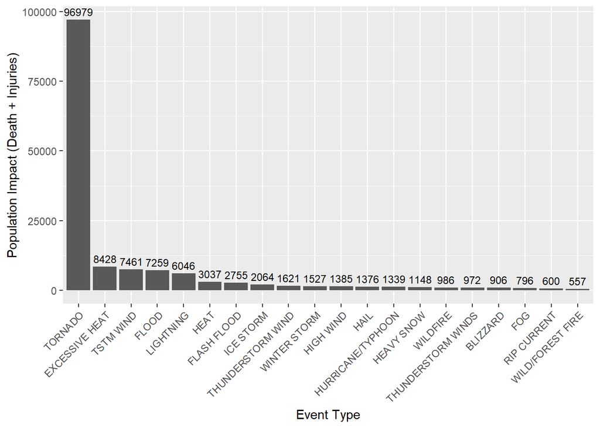

Figure 1: Population Health Impact by Event Type

```r
# Aggregate by total injuries/deaths by category:
pop_data <- pop.impact.data %>% group_by(EVTYPE) %>%
  summarize(Total = sum(total_population_impact)) %>% arrange(desc(Total)) %>%
  slice(1:20) # Include top 20 EVTYPES

d <- transform(pop_data, EVTYPE=reorder(EVTYPE, -Total)) # Reorder data (high-low)

g1 <- ggplot(data=d, aes(EVTYPE, Total)) +
  geom_bar(stat="identity") +
  theme(axis.text.x = element_text(angle=45,hjust=1)) +
  xlab("Event Type") +
  ylab("Population Impact (Death + Injuries)") +
  geom_text(aes(label=Total), vjust=-0.5, size=3)

# Render Plot:
g1
```

### Ecomonic Impact

The economic impact is defined as the sum of the property and crop damage caused by each type of environemental event (in U.S. Dollars). The chart below shows the values for the top twenty events:

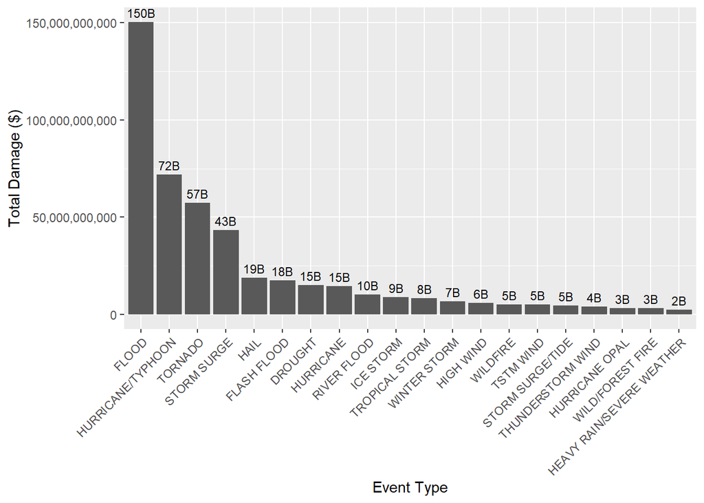

Figure 2: Economic Impact by Event Type

```r
damage_data <- econ.impact.data2 %>% group_by(EVTYPE) %>%
  summarize(Total = sum(total_dmg_impact)) %>% arrange(desc(Total)) %>%
   slice(1:20) # Include top 20 EVTYPES

d2 <- transform(damage_data, EVTYPE=reorder(EVTYPE, -Total)) # Reorder data (high-low)

g2 <- ggplot(data=d2, aes(EVTYPE, Total)) +
  geom_bar(stat="identity") +
  theme(axis.text.x = element_text(angle=45,hjust=1)) +
  scale_y_continuous(labels=scales::comma) +
  xlab("Event Type") +
  ylab("Total Damage ($)") +
  geom_text(aes(label=paste0(round(Total/1000000000,0),"B")), vjust=-0.5, size=3)

# Render Plot:
g2
```

## Conclusion

Based on the provided data, the following conclusions can be drawn:

#### 1. Population Health Impact

Tornadoes are the primary cause of injuries/deaths by a large margin. Excessive heat, Thunderstorm Wind, Flood, and Lightning (the next highest events) do not compare in terms of the impact.

#### 2. Economic Impact

Flood damage causes the most economic impact, followed by Hurricanes/Typhoons, Tornadoes, Storm Surges and Hail.

*All data/scripts used for analysis can be found at: https://github.com/dklemfus/Data_Science_JH_Reproducible_Research_Project_02*